# Data-driven Discovery

- true value = 0.4
- range of $\sigma$ = [0, 1]

# Black-Scholes

## 3 l 10 n:

[output not shown]

filename:

- BS_3_l_10_n_1_fold_variable_fitsolver_alpha_1_rep_1

# Black-Scholes

## 3 l 20 n:

| **$\alpha$** | **0.25** | **0.50** | **0.75** | $\space$ | **CV** |
| --- | --- | --- | --- | --- | --- |
| $\space$ $\space$ | **L2 error $u_{test}$** | **L2 error $u_{test}$** | **L2 error $u_{test}$** | $\space$ | **L2 error $u_{test}$** |
| **fold 1** | 3.2989e-03 (0.3921) | 3.0088e-03 (0.3938) | **2.9856e-03 (0.3942)** | $\space$ | 3.2991e-03 ($\alpha$ = 0.25) |
| **fold 2** | **4.4131e-03 (0.3916)** | 5.4965e-03 (0.3921) | 5.0776e-03 (0.3934) | $\space$ | 5.4966e-03 ($\alpha$ = 0.50) |
| **fold 3** | **3.0745e-03 (0.3923)** | 3.0916e-03 (0.3935) | 3.1715e-03 (0.3940) | $\space$ | 3.0916e-03 ($\alpha$ = 0.50) |
| **fold 4** | 3.1603e-03 (0.3917) | **3.0686e-03 (0.3931)** | 3.0912e-03 (0.3938) | $\space$ | 3.0911e-03 ($\alpha$ = 0.75) |
| **Average** $\space$ | **3.5059e-03** | 3.7667e-03 | 3.6445e-03 | $\space$ | 3.8335e-03 |

filename:

- BS_3_l_20_n_1_fold_variable_fitsolver_alpha_1_rep_1
- BS_%d*l*%d_n*fold*%d_variable_fitsolver_rep_1_revised

# Black-Scholes

## 4 l 10 n:

| **$\alpha$** | **0.25** | **0.50** | **0.75** | $\space$ |
| --- | --- | --- | --- | --- |
| $\space$ $\space$ | **L2 error $u_{test}$** | **L2 error $u_{test}$** | **L2 error $u_{test}$** | $\space$ |
| **fold 1** | **2.7679e-03 (0.3925)** | 2.8330e-03 (0.3933) | 2.7990e-03 (0.3943) | $\space$ |
| **fold 2** | 5.4703e-02 (0.0000) | 4.8276e-02 (0.0000) | **4.6798e-02 (0.0000)** | $\space$ |
| **fold 3** | 2.3702e-03 (0.3932) | 2.3563e-03 (0.3939) | **2.2848e-03 (0.3943)** | $\space$ |
| **fold 4** | **3.0052e-03 (0.3919)** | 3.0916e-03 (0.3925) | 4.0230e-03 (0.3934) | $\space$ |
| **Average** $\space$ | 2.6474e-02 | 2.3395e-02 | **2.2723e-02** | $\space$ |

filename:

- BS_4_l_10_n_1_fold_variable_fitsolver_alpha_1_rep_1

# Black-Scholes

## 4 l 20 n:

[output not shown]

filename:

- BS_4_l_20_n_1_fold_variable_fitsolver_alpha_1_rep_1

# Data-driven Discovery

- true value:
  - sigma: 1.83
  - gamma: 0.8
- range:
  - $\sigma$ = [0, 3]
  - $\gamma$ = [0, 2]

# CEV

## 3 l 10 n:

| **$\alpha$** | **0.25** | **0.50** | **0.75** | $\space$ |
| --- | --- | --- | --- | --- |
| $\space$ $\space$ | **L2 error $u_{test}$** | **L2 error $u_{test}$** | **L2 error $u_{test}$** | $\space$ |
| **fold 1** | **5.4238e-03 (1.8145, 0.7983)** | 5.4948e-03 (1.8181, 0.7990) | 5.5895e-03 (1.8233, 0.7993) | $\space$ |
| **fold 2** | 5.6768e-03 (1.8183, 0.7987) | **5.0850e-03 (1.8176, 0.7997)** | 5.4436e-03 (1.8241, 0.7993) | $\space$ |
| **fold 3** | 4.8625e-03 (1.8121, 0.7990) | **4.3980e-03 (1.8102, 0.8003)** | 5.1119e-03 (1.8322, 0.7988) | $\space$ |
| **fold 4** | 4.9520e-03 (1.7967, 0.7999) | 4.8143e-03 (1.8051, 0.8003) | **4.5539e-03 (1.8150, 0.8000)** | $\space$ |
| **Average** $\space$ | 5.2303e-03 | **4.9667e-03** | 5.1788e-03 | $\space$ |

filename:

- CEV_3_l_10_n_1_fold_variable_fitsolver_alpha_1_rep_1

# CEV

## 3 l 20 n:

| **$\alpha$** | **0.25** | **0.50** | **0.75** | $\space$ | **CV** |
| --- | --- | --- | --- | --- | --- |
| $\space$ $\space$ | **L2 error $u_{test}$** | **L2 error $u_{test}$** | **L2 error $u_{test}$** | $\space$ | **L2 error $u_{test}$** |
| **fold 1** | 3.4288e-03 (1.8151, 0.7996) | **3.0521e-03 (1.8123, 0.8003)** | 3.2785e-03 (1.8089, 0.8008) | $\space$ | 3.4288e-03 ($\alpha$ = 0.25) |
| **fold 2** | **3.6175e-03 (1.8115, 0.8001)** | 4.5376e-03 (1.8154, 0.7999) | 4.8383e-03 (1.8220, 0.7996) | $\space$ | 4.5376e-03 ($\alpha$ = 0.50) |
| **fold 3** | 3.2648e-03 (1.8079, 0.8004) | **3.1070e-03 (1.8091, 0.8007)** | 3.2263e-03 (1.8125, 0.8006) | $\space$ | 3.2263e-03 ($\alpha$ = 0.75) |
| **fold 4** | 3.4364e-03 (1.8089, 0.7999) | **2.9645e-03 (1.8124, 0.8002)** | 3.4651e-03 (1.8115, 0.8005) | $\space$ | 3.4364e-03 ($\alpha$ = 0.25) |
| **Average** $\space$ | **3.4368e-03** | 3.4461e-03 | 3.7339e-03 | $\space$ | 3.6734e-03 |

filename:

- CEV_3_l_20_n_1_fold_variable_fitsolver_alpha_1_rep_1
- CEV_3_l_20_n_1_fold_variable_fitsolver_rep_1

# CEV

## 4 l 10 n:

| **$\alpha$** | **0.25** | **0.50** | **0.75** | $\space$ |
| --- | --- | --- | --- | --- |
| $\space$ $\space$ | **L2 error $u_{test}$** | **L2 error $u_{test}$** | **L2 error $u_{test}$** | $\space$ |
| **fold 1** | 4.8218e-03 (1.8123, 0.7991) | 4.7010e-03 (1.8189, 0.7994) | **3.0667e-03 (1.8182, 0.8002)** | $\space$ |
| **fold 2** | 5.5461e-03 (1.8113, 0.7995) | **3.9514e-03 (1.8143, 0.8001)** | 5.1901e-03 (1.8209, 0.7996) | $\space$ |
| **fold 3** | 3.6446e-03 (1.8121, 0.8001) | 3.1615e-03 (1.8160, 0.8003) | **2.7102e-03 (1.8230, 0.8000)** | $\space$ |
| **fold 4** | **3.4564e-03 (1.8090, 0.8000)** | 3.6911e-03 (1.8101, 0.8001) | 3.7333e-03 (1.8151, 0.8002) | $\space$ |
| **Average** $\space$ | 4.4212e-03 | 3.9217e-03 | **3.7662e-03** | $\space$ |

filename:

- CEV_4_l_10_n_1_fold_variable_fitsolver_alpha_1_rep_1

# CEV

## 4 l 20 n:

| **$\alpha$** | **0.25** | **0.50** | **0.75** | $\space$ |
| --- | --- | --- | --- | --- |
| $\space$ $\space$ | **L2 error $u_{test}$** | **L2 error $u_{test}$** | **L2 error $u_{test}$** | $\space$ |
| **fold 1** | 3.1313e-03 (1.8075, 0.8003) | 2.8985e-03 (1.8106, 0.8005) | **2.5802e-03 (1.8209, 0.8000)** | $\space$ |
| **fold 2** | 3.8519e-03 (1.8079, 0.8004) | 4.0195e-03 (1.8080, 0.8005) | **2.9784e-03 (1.8095, 0.8011)** | $\space$ |
| **fold 3** | 2.8712e-03 (1.8080, 0.8006) | 2.7450e-03 (1.8136, 0.8004) | **2.7087e-03 (1.8154, 0.8004)** | $\space$ |
| **fold 4** | 2.8519e-03 (1.8016, 0.8008) | 2.8837e-03 (1.8033, 0.8009) | **2.7889e-03 (1.8057, 0.8011)** | $\space$ |
| **Average** $\space$ | 3.1854e-03 | 3.1573e-03 | **2.7634e-03** | $\space$ |

filename:

- CEV_4_l_20_n_1_fold_variable_fitsolver_alpha_1_rep_1

```python
import pickle
import numpy as np

Total_error_u_test_num = 0
Total_error_u_test_den = 0

# j indicates fold
for j in range(1,5):
    file = open('CEV_3_l_20_n_%d_fold_variable_fitsolver_rep_1'%(j),'rb')
    data = pickle.load(file)
    file.close()

    alpha_opt = data['alpha']

    if alpha_opt == 0.25:
        file = open('CEV_3_l_20_n_%d_fold_variable_fitsolver_alpha_1_rep_1'%(j),'rb')
        data = pickle.load(file)
        file.close()
    elif alpha_opt == 0.50:
        file = open('CEV_3_l_20_n_%d_fold_variable_fitsolver_alpha_2_rep_1'%(j),'rb')
        data = pickle.load(file)
        file.close()
    elif alpha_opt == 0.75:
        file = open('CEV_3_l_20_n_%d_fold_variable_fitsolver_alpha_3_rep_1'%(j),'rb')
        data = pickle.load(file)
        file.close()
    #elif alpha_opt == 0.75:
    #    file = open('CEV_3_l_20_n_%d_fold_variable_fitsolver_alpha_4_rep_1'%(j),'rb')
    #    data = pickle.load(file)
    #    file.close()
    #else:
    #    file = open('CEV_3_l_20_n_%d_fold_variable_fitsolver_alpha_5_rep_1'%(j),'rb')
    #    data = pickle.load(file)
    #    file.close()

    u_test_tot = data['u_test_tot']
    u_test_pred = data['u_test_pred']
    K_test_tot = data['K_test_tot']

    error_u_test_num = (np.linalg.norm(u_test_tot*K_test_tot-u_test_pred*K_test_tot))**2
    error_u_test_den = (np.linalg.norm(u_test_tot*K_test_tot))**2
    print('%.4e'%np.sqrt(error_u_test_num/error_u_test_den))
    print('alpha_opt = %s'%alpha_opt)
    print('\n')
    Total_error_u_test_num += error_u_test_num
    Total_error_u_test_den += error_u_test_den

print('%.4e'%np.sqrt(Total_error_u_test_num/Total_error_u_test_den))
```

```
3.4288e-03
alpha_opt = 0.25


4.5376e-03
alpha_opt = 0.5


3.2263e-03
alpha_opt = 0.75


3.4364e-03
alpha_opt = 0.25


3.6734e-03
```

```python
import pickle
import numpy as np

Total_error_u_test_num = 0
Total_error_u_test_den = 0

for j in range(1,5):
    file = open('BS_3_l_10_n_fold_%d_variable_fitsolver_rep_1'%(j),'rb')
    data = pickle.load(file)
    file.close()

    u_test_tot = data['u_test_tot']
    u_test_pred = data['u_test_pred']
    K_test_tot = data['K_test_tot']
    alpha_opt = data['alpha']

    error_u_test_num = (np.linalg.norm(u_test_tot*K_test_tot-u_test_pred*K_test_tot))**2
    error_u_test_den = (np.linalg.norm(u_test_tot*K_test_tot))**2
    print('%.4e '%np.sqrt(error_u_test_num/error_u_test_den) + '(\u03B1 = %.2f)'%alpha_opt)
    #print('alpha_opt = %s'%alpha_opt)
    #print('\n')
    Total_error_u_test_num += error_u_test_num
    Total_error_u_test_den += error_u_test_den

print('%.4e'%np.sqrt(Total_error_u_test_num/Total_error_u_test_den))
```

```
5.4963e-02 (α = 0.25)
5.7436e-03 (α = 0.50)
4.0043e-03 (α = 0.25)
5.5914e-03 (α = 0.75)
2.8218e-02
```

```python
import pickle
import numpy as np
for i in range(1,5):

    Total_error_u_test_num = 0
    Total_error_u_test_den = 0
    error_bar = '|'
    for j in range(1,4):
        file = open('CEV_4_l_20_n_%d_fold_variable_fitsolver_alpha_%d_rep_1'%(i,j),'rb')
        data = pickle.load(file)
        file.close()

        u_test_tot = data['u_test_tot']
        u_test_pred = data['u_test_pred']
        K_test_tot = data['K_test_tot']
        sigma = data['sigma']
        gamma = data['gamma']

        error_u_test_num = (np.linalg.norm(u_test_tot*K_test_tot-u_test_pred*K_test_tot))**2
        error_u_test_den = (np.linalg.norm(u_test_tot*K_test_tot))**2
        error = ' %.4e (%.4f, %.4f) |'%(np.sqrt(error_u_test_num/error_u_test_den),sigma,gamma)
        #print('%.4e |'%np.sqrt(error_u_test_num/error_u_test_den))

        error_bar = error_bar + error

        #print(error_bar)

        #Total_error_u_test_num += error_u_test_num
        #Total_error_u_test_den += error_u_test_den

    #error_bar = error_bar + ' %.4e |'%np.sqrt(Total_error_u_test_num/Total_error_u_test_den)
    print(error_bar)
    #print('%.4e'%np.sqrt(Total_error_u_test_num/Total_error_u_test_den))
    #print('\n')

import pickle
import numpy as np
error_bar = '|'
for i in range(1,4):

    Total_error_u_test_num = 0
    Total_error_u_test_den = 0

    for j in range(1,5):
        file = open('CEV_4_l_20_n_%d_fold_variable_fitsolver_alpha_%d_rep_1'%(j,i),'rb')
        data = pickle.load(file)
        file.close()

        u_test_tot = data['u_test_tot']
        u_test_pred = data['u_test_pred']
        K_test_tot = data['K_test_tot']

        error_u_test_num = (np.linalg.norm(u_test_tot*K_test_tot-u_test_pred*K_test_tot))**2
        error_u_test_den = (np.linalg.norm(u_test_tot*K_test_tot))**2

        Total_error_u_test_num += error_u_test_num
        Total_error_u_test_den += error_u_test_den
    error = ' %.4e |'%np.sqrt(Total_error_u_test_num/Total_error_u_test_den)
    error_bar = error_bar + error
print(error_bar)
```

```
| 3.1313e-03 (1.8075, 0.8003) | 2.8985e-03 (1.8106, 0.8005) | 2.5802e-03 (1.8209, 0.8000) |
| 3.8519e-03 (1.8079, 0.8004) | 4.0195e-03 (1.8080, 0.8005) | 2.9784e-03 (1.8095, 0.8011) |
| 2.8712e-03 (1.8080, 0.8006) | 2.7450e-03 (1.8136, 0.8004) | 2.7087e-03 (1.8154, 0.8004) |
| 2.8519e-03 (1.8016, 0.8008) | 2.8837e-03 (1.8033, 0.8009) | 2.7889e-03 (1.8057, 0.8011) |
| 3.1854e-03 | 3.1573e-03 | 2.7634e-03 |
```

```python
import pickle
import numpy as np
for i in range(1,6):

    Total_error_u_test_num = 0
    Total_error_u_test_den = 0

    for j in range(1,5):
        file = open('BS_4_l_20_n_%d_fold_constant_fitsolver_alpha_%d_rep'%(j,i),'rb')
        data = pickle.load(file)
        file.close()

        u_test_tot = data['u_test_tot']
        u_test_pred = data['u_test_pred']
        K_test_tot = data['K_test_tot']

        error_u_test_num = (np.linalg.norm(u_test_tot*K_test_tot-u_test_pred*K_test_tot))**2
        error_u_test_den = (np.linalg.norm(u_test_tot*K_test_tot))**2
        print('%.4e'%np.sqrt(error_u_test_num/error_u_test_den))

        Total_error_u_test_num += error_u_test_num
        Total_error_u_test_den += error_u_test_den

    print('%.4e'%np.sqrt(Total_error_u_test_num/Total_error_u_test_den))
    print('\n')
```

```
3.1343e-03
4.8403e-03
3.4696e-03
4.3566e-03
3.9959e-03


2.8967e-03
4.7137e-03
3.2839e-03
3.8565e-03
3.7304e-03


2.6130e-03
5.8310e-03
3.0043e-03
3.5663e-03
3.9048e-03


2.3988e-03
5.9128e-03
3.0805e-03
4.7414e-03
4.2324e-03


2.9918e-03
8.3947e-03
3.3601e-03
3.4795e-03
4.9653e-03
```

# Real Data

### Near the money vs All (1 year)

Near the money:

[output not shown]

filename:

- Real_3_l_20*n*%d_fold_nn_fitsolver*alpha*%d_ntm_1_year_rep

All options:

| **$\alpha$** | **0** | **0.25** | **0.50** | **0.75** | **1** |
| --- | --- | --- | --- | --- | --- |
| $\space$ $\space$ | **L2 error $u_{test}$** | **L2 error $u_{test}$** | **L2 error $u_{test}$** | **L2 error $u_{test}$** | **L2 error $u_{test}$** |
| **fold 1** | 5.0418e-02 | 1.5322e-02 | 1.7280e-02 | 1.5983e-02 | **1.3529e-02** |
| **fold 2** | 5.1867e-02 | 1.5195e-02 | 1.9315e-02 | 1.3797e-02 | **1.2442e-02** |
| **fold 3** | 5.0702e-02 | 1.5042e-02 | 1.6559e-02 | 2.0565e-02 | **1.4019e-02** |
| **fold 4** | 5.3209e-02 | 2.9523e-02 | 1.2030e-02 | 1.1815e-02 | **1.1654e-02** |
| **Average** $\space$ | 5.1556e-02 | 1.9703e-02 | 1.6547e-02 | 1.5864e-02 | **1.2944e-02** |

filename:

- Real_3_l_20*n*%d_fold_nn_fitsolver*alpha*%d_all_1_year_rep

### 6 months vs 1 year (all options)

6 months:

| **$\alpha$** | **0** | **0.25** | **0.50** | **0.75** | **1** |
| --- | --- | --- | --- | --- | --- |
| $\space$ $\space$ | **L2 error $u_{test}$** | **L2 error $u_{test}$** | **L2 error $u_{test}$** | **L2 error $u_{test}$** | **L2 error $u_{test}$** |
| **fold 1** | 4.5489e-02 | 1.2371e-02 | 1.3211e-02 | 1.4399e-02 | **8.5959e-03** |
| **fold 2** | 4.5537e-02 | 1.2473e-02 | 1.0963e-02 | 8.7567e-03 | **8.3282e-03** |
| **fold 3** | 4.7351e-02 | 1.7211e-02 | 1.4279e-02 | 2.0396e-02 | **9.3477e-03** |
| **fold 4** | 4.6787e-02 | 9.6061e-03 | 8.3373e-03 | 8.2643e-03 | **7.7400e-03** |
| **Average** $\space$ | 4.6284e-02 | 1.3157e-02 | 1.1890e-02 | 1.3764e-02 | **8.5138e-03** |

filename:

- Real_3_l_20*n*%d_fold_nn_fitsolver*alpha*%d_all_6_months_rep

1 year:

| **$\alpha$** | **0** | **0.25** | **0.50** | **0.75** | **1** |
| --- | --- | --- | --- | --- | --- |
| $\space$ $\space$ | **L2 error $u_{test}$** | **L2 error $u_{test}$** | **L2 error $u_{test}$** | **L2 error $u_{test}$** | **L2 error $u_{test}$** |
| **fold 1** | 5.0418e-02 | 1.5322e-02 | 1.7280e-02 | 1.5983e-02 | **1.3529e-02** |
| **fold 2** | 5.1867e-02 | 1.5195e-02 | 1.9315e-02 | 1.3797e-02 | **1.2442e-02** |
| **fold 3** | 5.0702e-02 | 1.5042e-02 | 1.6559e-02 | 2.0565e-02 | **1.4019e-02** |
| **fold 4** | 5.3209e-02 | 2.9523e-02 | 1.2030e-02 | 1.1815e-02 | **1.1654e-02** |
| **Average** $\space$ | 5.1556e-02 | 1.9703e-02 | 1.6547e-02 | 1.5864e-02 | **1.2944e-02** |

filename:

- Real_3_l_20*n*%d_fold_nn_fitsolver*alpha*%d_all_1_year_rep

### 6 months trimmed

| **$\alpha$** | **0** | **0.25** | **0.50** | **0.75** | **1** |
| --- | --- | --- | --- | --- | --- |
| $\space$ $\space$ | **L2 error $u_{test}$** | **L2 error $u_{test}$** | **L2 error $u_{test}$** | **L2 error $u_{test}$** | **L2 error $u_{test}$** |
| **fold 1** | 3.6755e-02 | 1.0601e-02 | **7.8274e-03** | 8.2139e-03 | 7.9488e-03 |
| **fold 2** | 3.7306e-02 | 8.8410e-03 | 7.9507e-03 | 7.6380e-03 | **7.2970e-03** |
| **fold 3** | 4.0748e-02 | 7.8835e-03 | 7.5371e-03 | 7.4719e-03 | **7.3334e-03** |
| **fold 4** | 3.8967e-02 | 9.0957e-03 | 7.4998e-03 | 7.5199e-03 | **7.0315e-03** |
| **Average** $\space$ | 3.8490e-02 | 9.1257e-03 | 7.7088e-03 | 7.7087e-03 | **7.4035e-03** |

filename:

- Real_3_l_20*n*%d_fold_nn_fitsolver*alpha*%d_all_6_months_trimmed_rep

### 6 months trimmed

| **$\alpha$** | **0** | **0.25** | **0.50** | **0.75** | **1** |
| --- | --- | --- | --- | --- | --- |
| $\space$ $\space$ | **L2 error $u_{test}$** | **L2 error $u_{test}$** | **L2 error $u_{test}$** | **L2 error $u_{test}$** | **L2 error $u_{test}$** |
| **fold 1** | 4.6685e-02 | 7.9846e-03 | 7.8389e-03 | 7.9148e-03 | **7.7055e-03** |
| **fold 2** | 3.7647e-02 | 7.9587e-03 | 7.6624e-03 | 7.6060e-03 | **7.2237e-03** |
| **fold 3** | 4.2248e-02 | 7.7666e-03 | 7.5728e-03 | 7.3834e-03 | **7.2254e-03** |
| **fold 4** | 4.4592e-02 | 7.9734e-03 | 7.6120e-03 | 7.6910e-03 | **7.4413e-03** |
| **Average** $\space$ | 4.2781e-02 | 7.9198e-03 | 7.6697e-03 | 7.6451e-03 | **7.3936e-03** |

filename:

- Real_4_l_20*n*%d_fold_nn_fitsolver*alpha*%d_all_6_months_trimmed_rep

### 6 months trimmed

| **$\alpha$** | **0** | **0.25** | **0.50** | **0.75** | **1** |
| --- | --- | --- | --- | --- | --- |
| $\space$ $\space$ | **L2 error $u_{test}$** | **L2 error $u_{test}$** | **L2 error $u_{test}$** | **L2 error $u_{test}$** | **L2 error $u_{test}$** |
| **fold 1** | 4.6356e-02 | 8.5104e-03 | 7.8024e-03 | 7.8428e-03 | **7.7379e-03** |
| **fold 2** | 3.6737e-02 | 7.6613e-03 | 7.4700e-03 | **7.3512e-03** | 7.4254e-03 |
| **fold 3** | 4.2218e-02 | 7.6613e-03 | 7.3932e-03 | **7.3019e-03** | 7.3986e-03 |
| **fold 4** | 4.4514e-02 | 7.6657e-03 | 7.4374e-03 | **7.3161e-03** | 7.4794e-03 |
| **Average** $\space$ | 4.2458e-02 | 7.8716e-03 | 7.5228e-03 | **7.4497e-03** | 7.5068e-03 |

filename:

- Real_4_l_30*n*%d_fold_nn_fitsolver*alpha*%d_all_6_months_trimmed_rep

### 6 months trimmed (excluding the boundary points)

| **$\alpha$** | **0** | **0.25** | **0.50** | **0.75** | **1** |
| --- | --- | --- | --- | --- | --- |
| $\space$ $\space$ | **L2 error $u_{test}$** | **L2 error $u_{test}$** | **L2 error $u_{test}$** | **L2 error $u_{test}$** | **L2 error $u_{test}$** |
| **fold 1** | 5.1299e-02 | 9.3896e-03 | 8.6017e-03 | 8.6477e-03 | **8.5296e-03** |
| **fold 2** | 4.0281e-02 | 8.3635e-03 | 8.1490e-03 | **8.0243e-03** | 8.1002e-03 |
| **fold 3** | 4.7148e-02 | 8.4320e-03 | 8.1274e-03 | **8.0252e-03** | 8.0833e-03 |
| **fold 4** | 4.9029e-02 | 8.4344e-03 | 8.1847e-03 | **8.0515e-03** | 8.2323e-03 |
| **Average** $\space$ | 4.6924e-02 | 8.6503e-03 | 8.2614e-03 | **8.1826e-03** | 8.2315e-03 |

filename:

- Real_4_l_30*n*%d_fold_nn_fitsolver*alpha*%d_all_6_months_trimmed_rep

### 6 months trimmed (excluding the boundary points) $\tau < 1.2$

| **$\alpha$** | **0** | **0.25** | **0.50** | **0.75** | **1** |
| --- | --- | --- | --- | --- | --- |
| $\space$ $\space$ | **L2 error $u_{test}$** | **L2 error $u_{test}$** | **L2 error $u_{test}$** | **L2 error $u_{test}$** | **L2 error $u_{test}$** |
| **fold 1** | 5.1299e-02 | 9.3896e-03 | 8.6017e-03 | 8.6477e-03 | **8.5296e-03** |
| **fold 2** | 4.0281e-02 | 8.3635e-03 | 8.1490e-03 | **8.0243e-03** | 8.1002e-03 |
| **fold 3** | 4.7148e-02 | 8.4320e-03 | 8.1274e-03 | **8.0252e-03** | 8.0833e-03 |
| **fold 4** | 4.9029e-02 | 8.4344e-03 | 8.1847e-03 | **8.0515e-03** | 8.2323e-03 |
| **Average** $\space$ | 4.6924e-02 | 8.6503e-03 | 8.2614e-03 | **8.1826e-03** | 8.2315e-03 |

filename:

### 6 months trimmed w/o b2

| **$\alpha$** | **0** | **0.25** | **0.50** | **0.75** | **1** |
| --- | --- | --- | --- | --- | --- |
| $\space$ $\space$ | **L2 error $u_{test}$** | **L2 error $u_{test}$** | **L2 error $u_{test}$** | **L2 error $u_{test}$** | **L2 error $u_{test}$** |
| **fold 1** | 4.4222e-02 | 1.4126e-02 | 9.3594e-03 | 1.2164e-02 | **8.1566e-03** |
| **fold 2** | 3.7584e-02 | **9.5038e-03** | 1.9789e-02 | 1.3500e-02 | 1.2015e-02 |
| **fold 3** | 4.2464e-02 | 1.7061e-02 | 1.5137e-02 | 1.1019e-02 | **8.7688e-03** |
| **fold 4** | 4.7599e-02 | 9.0457e-03 | 1.0755e-02 | 8.7913e-03 | **7.9677e-03** |
| **Average** $\space$ | 4.3061e-02 | 1.2830e-02 | 1.4416e-02 | 1.1529e-02 | **9.4052e-03** |

filename:

- Real_4_l_30*n*%d_fold_nn_fitsolver*alpha*%d_all_6_months_trimmed_rep

# Plot $\sigma_{nn}$ and implied volatility

## Find implied volatility

### newton_raphson

```python
from NR_Method import newton_raphson
x = tot[:,0:1]
tau = tot[:,1:2]
Vmkt = tot[:,2:3]*tot[:,4:5]
ls = []
for dat in np.hstack([x,tau,Vmkt]):
    ls.append(newton_raphson(s=2919.4,t=0,K=2919.4/dat[0],T=dat[1],r=0.0167,Vmkt=dat[2],sigma_init=0.5))
```

[output not shown]

[output not shown]

### scipy.optimize.newton

```python
def f(sigma,s,t,K,T,r,Vmkt):

    d1 = (np.log(s/K)+ (r + (sigma**2)/2)*(T-t))/(sigma*np.sqrt(T-t))
    d2 = d1 - sigma*(np.sqrt(T-t))

    f = s*scipy.stats.norm.cdf(d1) - K*np.exp(-r*(T-t))*scipy.stats.norm.cdf(d2) - Vmkt

    return f

def fder(sigma,s,t,K,T,r,Vmkt):

    d1 = (np.log(s/K)+ (r + (sigma**2)/2)*(T-t))/(sigma*np.sqrt(T-t))
    d2 = d1 - sigma*(np.sqrt(T-t))

    fprime = s*(1/np.sqrt(2*np.pi))*np.exp((-d1**2)/2)*np.sqrt(T-t)

    return fprime
```

```python
from scipy import optimize

s = tot[:,0:1]*tot[:,4:5]
t = np.repeat(0.,tot.shape[0])[:,None]
K = tot[:,4:5]
T = tot[:,1:2]
r = np.repeat(0.0167,tot.shape[0])[:,None]
Vmkt = tot[:,3:4]*tot[:,4:5]
sigma = np.repeat(0.5,tot.shape[0])[:,None]
vec_res = optimize.newton(f, sigma, fprime=fder, args=(s,t,K,T,r,Vmkt))
```

### newton_raphson (another version)

```python
def newton_vol_call(S, K, T, C, r, sigma):

    #S: spot price
    #K: strike price
    #T: time to maturity
    #C: Call value
    #r: interest rate
    #sigma: volatility of underlying asset

    d1 = (np.log(S / K) + (r + 0.5 * sigma ** 2) * T) / (sigma * np.sqrt(T))
    d2 = (np.log(S / K) + (r - 0.5 * sigma ** 2) * T) / (sigma * np.sqrt(T))

    fx = S * si.norm.cdf(d1, 0.0, 1.0) - K * np.exp(-r * T) * si.norm.cdf(d2, 0.0, 1.0) - C

    vega = (1 / np.sqrt(2 * np.pi)) * S * np.sqrt(T) * np.exp(-(si.norm.cdf(d1, 0.0, 1.0) ** 2) * 0.5)

    tolerance = 1e-5
    x0 = sigma
    xnew  = x0
    xold = x0 - 1

    while abs(xnew - xold) > tolerance:

        xold = xnew
        xnew = xnew - ( fx  / vega)

        return abs(xnew)
```

```python
import scipy.stats as si
x = tot[:,0:1]
tau = tot[:,1:2]
Vmkt = tot[:,2:3]*tot[:,4:5]
K = tot[:,4:5]
ls = []
for dat in np.hstack([x,tau,Vmkt,K]):
    ls.append(newton_vol_call(S=2919.4, K=dat[3], T=dat[1], C=dat[2], r=0.0167, sigma=0.5))
```

### scipy.optimize.bisect

```python
def V(sigma, s,t,K,T,r, Vmkt):

    #s : stock price
    #t : time
    #K : strike price
    #T : maturity
    #r : risk free interest rate
    #sigma: volatility

    d1 = (np.log(s/K)+ (r + (sigma**2)/2)*(T-t))/(sigma*np.sqrt(T-t))
    d2 = d1 - sigma*(np.sqrt(T-t))
    V = s*scipy.stats.norm.cdf(d1) - K*np.exp(-r*(T-t))*scipy.stats.norm.cdf(d2) -Vmkt

    return V
```

```python
from scipy import optimize
import scipy.stats
x = tot[:,0:1]
tau = tot[:,1:2]
Vmkt = tot[:,3:4]*tot[:,4:5]
K = tot[:,4:5]
ls = []
counter = 0
for dat in np.hstack([x,tau,Vmkt,K]):
    s=2919.4
    t=0
    K=dat[3]
    T=dat[1]
    r=0.0167
    Vmkt=dat[2]
    ls.append(optimize.bisect(V, 0, 100, args=(s,t,K,T,r, Vmkt)))
    print(counter)
    counter+=1
```

[output not shown]

### Bisection

```python
u_min = np.maximum((tot[:,0:1]-np.exp(-0.0167*tot[:,1:2])),0)
for q in range(tot.shape[0]):
    if tot[q,3] < u_min[q]:
        tot[q,3] = u_min[q]
```

```python
import scipy.stats
def V(s,t,K,T,r,sigma):

    #s : stock price
    #t : time
    #K : strike price
    #T : maturity
    #r : risk free interest rate
    #sigma: volatility

    d1 = (np.log(s/K)+ (r + (sigma**2)/2)*(T-t))/(sigma*np.sqrt(T-t))
    d2 = d1 - sigma*(np.sqrt(T-t))
    V = s*scipy.stats.norm.cdf(d1) - K*np.exp(-r*(T-t))*scipy.stats.norm.cdf(d2)

    return V

def bisection(s,t,K,T,r,Vmkt, counter):

    #Vmkt : market price

    tolerance = 1e-10

    a = 0
    b = 100
    y1 = V(s,t,K,T,r,a)-Vmkt
    y2 = V(s,t,K,T,r,b)-Vmkt

    if y1*y2 > 0:
        print("%d: Bisection method fails."%counter)



    while (b - a) > tolerance:

        m = (a+b)/2
        y1 = V(s,t,K,T,r,a)-Vmkt
        y2 = V(s,t,K,T,r,m)-Vmkt

        if (y1<0 and y2>0) or (y1>0 and y2<0):

            b = m

        else:

            a = m

    #    counter += 1
    #    print('Interval is [%f,%f]'%(a,b))
    #print('Implied Volatility: {}'.format((a+b)/2))
    #print('No. of iteration: {}'.format(counter))

    return (a+b)/2


x = train_tot[:,0:1]
tau = train_tot[:,1:2]
Vmkt = train_tot[:,3:4]*train_tot[:,4:5]
ls = []
counter = 0
for dat in np.hstack([x,tau,Vmkt]):
    ls.append(bisection(s=2919.4,t=0,K=2919.4/dat[0],T=dat[1],r=0.0167,Vmkt=dat[2],counter=counter))
    counter += 1
    #ls.append(newton_raphson(s=2919.4,t=0,K=2919.4/dat[0],T=dat[1],r=0.0167,Vmkt=dat[2],sigma_init=0.5)
```

```
1: Bisection method fails.
4: Bisection method fails.
8: Bisection method fails.
9: Bisection method fails.
14: Bisection method fails.
18: Bisection method fails.
23: Bisection method fails.
24: Bisection method fails.
29: Bisection method fails.
31: Bisection method fails.
33: Bisection method fails.
35: Bisection method fails.
37: Bisection method fails.
41: Bisection method fails.
43: Bisection method fails.
```

[output cut: 971 more lines]

```python
h = np.concatenate([tot[:,4:5], tot[:,1:2], tot[:,6:7], tot[:,3:4]*tot[:,4:5]],1)
```

```python
for x in h:
    print(x)
```

[output not shown]

[output cut: 5237 more lines]

[output not shown]

```python
u_min = np.maximum((tot[5200,0:1]-np.exp(-0.0167*tot[5200,1:2])),0)
u_min
```

```
array([1.92620792])
```

```python
train_tot = train_tot[train_tot[:,6]!=99.99999999995453]
```

```python
def V(s,t,K,T,r,sigma):

    #s : stock price
    #t : time
    #K : strike price
    #T : maturity
    #r : risk free interest rate
    #sigma: volatility

    d1 = (np.log(s/K)+ (r + (sigma**2)/2)*(T-t))/(sigma*np.sqrt(T-t))
    d2 = d1 - sigma*(np.sqrt(T-t))
    Val = s*scipy.stats.norm.cdf(d1) - K*np.exp(-r*(T-t))*scipy.stats.norm.cdf(d2)

    return Val
i = 5200
V(2919.4,0,tot[i,4],tot[i,1],0.0167,0)
```

```
1926.2079238030383
```

```python
ls1 = np.array(ls)


train_tot = np.concatenate([train_tot,ls1[:,None]],1)
```

```python
import matplotlib.pyplot as plt
import pickle
import numpy as np
#file = open('Heston_4_l_20_n_1_constant_fitsolver_alpha_3_rep_v(with_train)','rb')
file = open('Real_4_l_30_n_1_fold_nn_fitsolver_alpha_3_all_6_months_trimmed_rep(with_train)','rb')
data = pickle.load(file)
file.close()

X_test_tot = data['X_test_tot']
u_test_pred = data['u_test_pred']
u_test_tot = data['u_test_tot']
K_test_tot = data['K_test_tot']
sigma_nn_test = data['sigma_nn_test']

X_train_tot = data['X_train_tot']
u_train_pred = data['u_train_pred']
u_train_tot = data['u_train_tot']
K_train_tot = data['K_train_tot']
sigma_nn_train = data['sigma_nn_train']

test_tot = np.concatenate((X_test_tot,u_test_pred, u_test_tot, K_test_tot, sigma_nn_test),axis=1)
train_tot = np.concatenate((X_train_tot,u_train_pred, u_train_tot, K_train_tot, sigma_nn_train),axis=1)
tot = np.concatenate([test_tot,train_tot])
```

```python
from scipy.interpolate import griddata

#tot = tot[tot[:,2] == np.unique(tot[:,2])[98]]

tot_t = tot[tot[:,1].argsort()][:,1:2]
tot_x = tot[tot[:,0].argsort()][:,0:1]
tot_K = tot[tot[:,4].argsort()][:,4:5]

tot_t_uni = np.unique(tot_t)
tot_x_uni = np.unique(tot_x)
tot_K_uni = np.unique(tot_K)

X, T = np.meshgrid(tot_x_uni, tot_t_uni)
K, T = np.meshgrid(tot_K_uni, tot_t_uni)


#sigma_nn = griddata(tot[:,0:2], tot[:,5:6], (X, T), method='cubic')
#imp_vol = griddata(tot[:,0:2], tot[:,7:8], (X, T), method='linear')

#log_x = np.concatenate([np.log(tot[:,0:1]),tot[:,1:2]],1)
#sigma_nn = griddata(log_x, abs(tot[:,5:6]), (X, T), method='cubic')

sigma_nn = griddata(tot[:,[0,1]], abs(tot[:,5:6]), (X, T), method='cubic')
imp_vol = griddata(train_tot[:,[0,1]], train_tot[:,6:7], (X, T), method='linear')
v = extrapolate_nans(X,T,np.squeeze(imp_vol))

#sigma_nn = griddata(tot[:,[4,1]], abs(tot[:,5:6]), (K, T), method='cubic')
#imp_vol = griddata(tot[:,[5,1]], tot[:,7:8], (K, T), method='linear')
```

```python
griddata(train_tot[:,[0,1]], train_tot[:,6:7], (X, T), method='linear').shape
```

```
(76, 340, 1)
```

```python
for x in v:
    print(x
         )
```

[output not shown]

[output cut: 4277 more lines]

[output not shown]

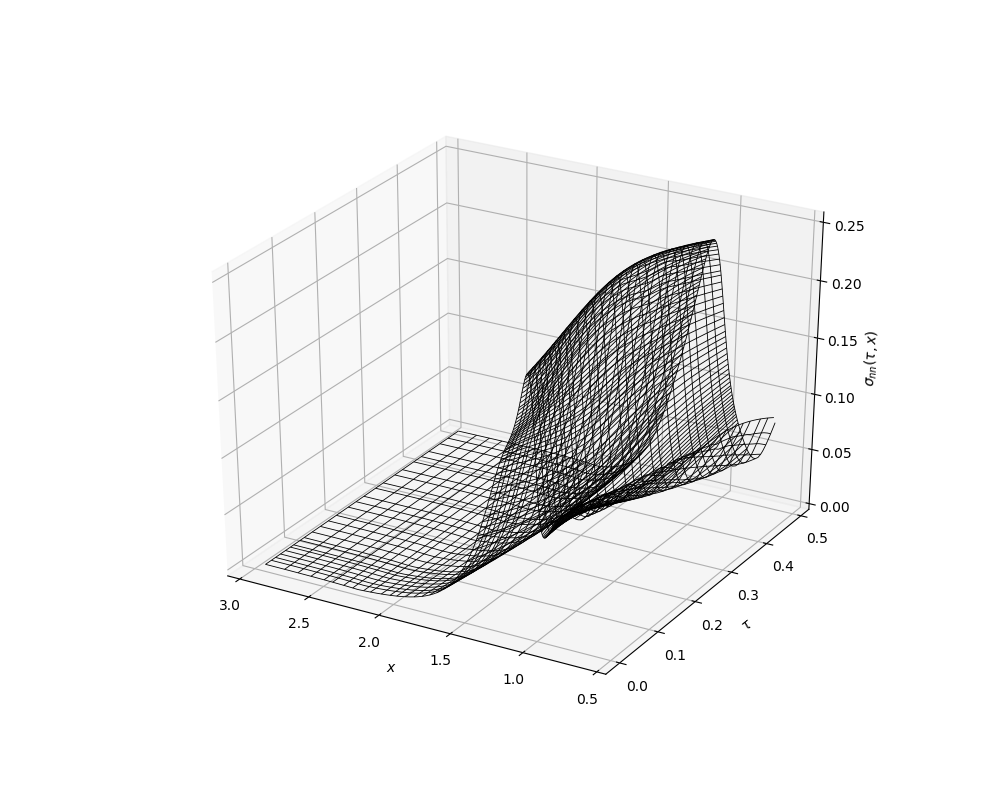

```python
import matplotlib.pyplot as plt
from mpl_toolkits.mplot3d import axes3d, Axes3D #<-- Note the capitalization!
%matplotlib nbagg
fig = plt.figure(figsize=(10,8))

ax = plt.axes(projection='3d')

#ax.scatter(tot[:,0],tot[:,1],abs(tot[:,5]),c='k')
ax.plot_wireframe(X,T,np.squeeze(sigma_nn), rstride=3, cstride=3, color='k',linewidth=0.6)

ax.set_xlabel('$x$')
ax.set_ylabel(r'$\tau$')
ax.set_zlabel(r'$\sigma_{nn}(\tau,x)$')
ax.invert_xaxis()
plt.show()
#fig.savefig(r'C:\Users\keeyh\Desktop\Yong How\LaTeX Documents\Real_4_l_30_n_1_fold_nn_fitsolver_alpha_3_all_6_months_trimmed_rep(with_train)_sigma_nn.pdf', bbox_inches='tight', pad_inches=0)
```

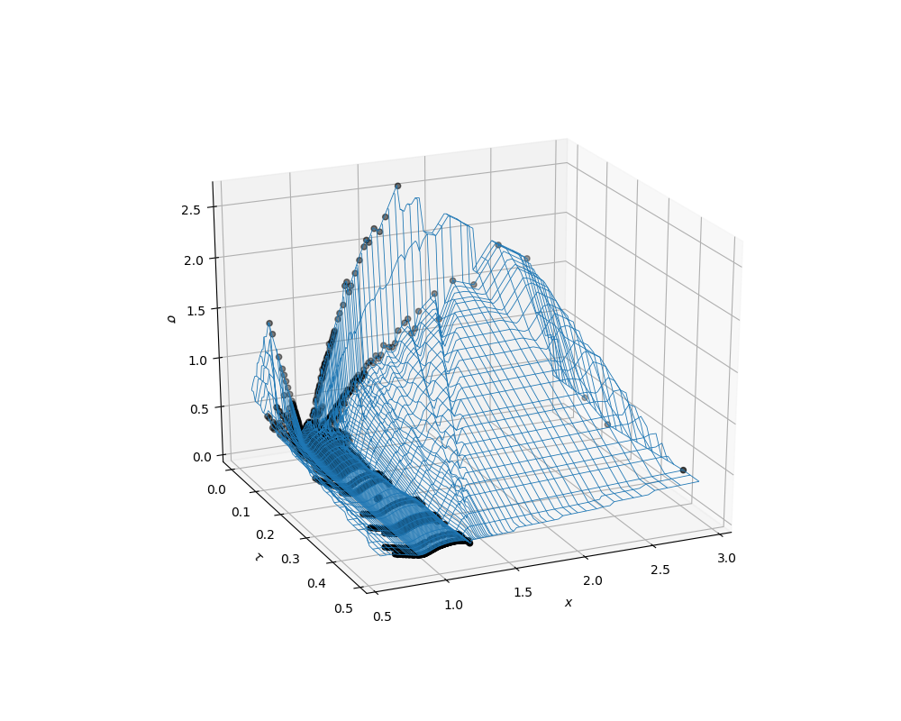

```python
import matplotlib.pyplot as plt
from mpl_toolkits.mplot3d import axes3d, Axes3D #<-- Note the capitalization!
%matplotlib nbagg
fig = plt.figure(figsize=(10,8))

ax = plt.axes(projection='3d')

ax.scatter(train_tot[:,0],train_tot[:,1],train_tot[:,6:7],c='k')
ax.plot_wireframe(X,T,np.squeeze(v), rstride=3, cstride=3,linewidth=0.6)


ax.set_xlabel('$x$')
ax.set_ylabel(r'$\tau$')
ax.set_zlabel(r'$\sigma$')
ax.invert_xaxis()
plt.show()
#fig.savefig(r'C:\Users\keeyh\Desktop\Yong How\LaTeX Documents\Three_half_4_l_20_n_1_constant_fitsolver_alpha_3_rep_v(with_train)_3d_rel_err_v2.pdf', bbox_inches='tight', pad_inches=0)
```

```python
x = T.flatten()[:,None]
y = X.flatten()[:,None]
z = v.flatten()[:,None]
coord = np.hstack([y,x,z])
coord.shape
```

```
(25840, 3)
```

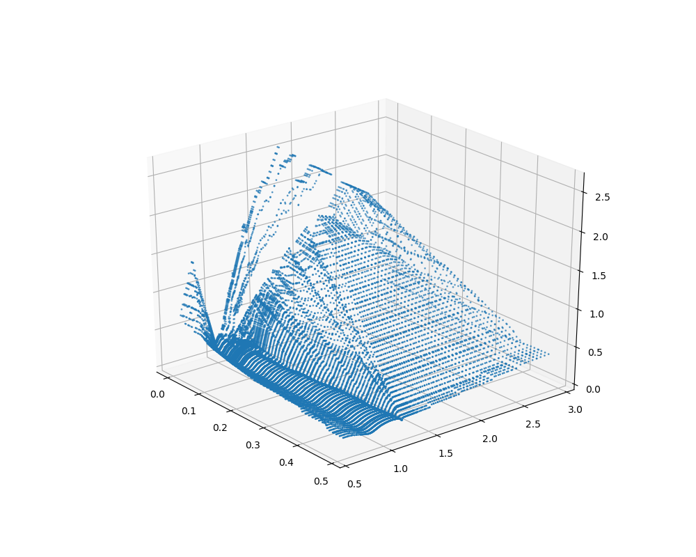

```python
fig = plt.figure(figsize=(10,8))

ax = plt.axes(projection='3d')

ax.scatter(x,y,z,s=1)
```

```python
c = []
for row1 in test_tot:
    #print(row1.shape)
    for row2 in coord:
        #print(row2.shape)

        if row2[0] == row1[0] and row2[1] == row1[1]:
            row1 = np.append(row1,row2[2])[None,:]
            c.append(row1)
            break
c = np.concatenate(c)
```

```python
def V(s,t,K,T,r,sigma):

    #s : stock price
    #t : time
    #K : strike price
    #T : maturity
    #r : risk free interest rate
    #sigma: volatility

    d1 = (np.log(s/K)+ (r + (sigma**2)/2)*(T-t))/(sigma*np.sqrt(T-t))
    d2 = d1 - sigma*(np.sqrt(T-t))
    Val = s*scipy.stats.norm.cdf(d1) - K*np.exp(-r*(T-t))*scipy.stats.norm.cdf(d2)

    return Val

l = []
for i in range(c.shape[0]):
    l.append(V(s=2919.4,t=0,K=c[i,4],T=c[i,1],r=0.0167,sigma=c[i,6]))
```

```python
i=2
V(s=2919.4,t=0,K=c[i,4],T=c[i,1],r=0.0167,sigma=c[i,6])
```

```
0.04173198561833802
```

```python
c = np.concatenate((c,np.array(l)[:,None]),1)
error_u_test_num = (np.linalg.norm(c[:,3]*c[:,4] - c[:,7]))**2
error_u_test_den = (np.linalg.norm(c[:,3]*c[:,4]))**2
np.sqrt(error_u_test_num/error_u_test_den)
```

```
0.018227995916356935
```

```python
np.array(l)[:,None].shape
```

```
(1313, 1)
```

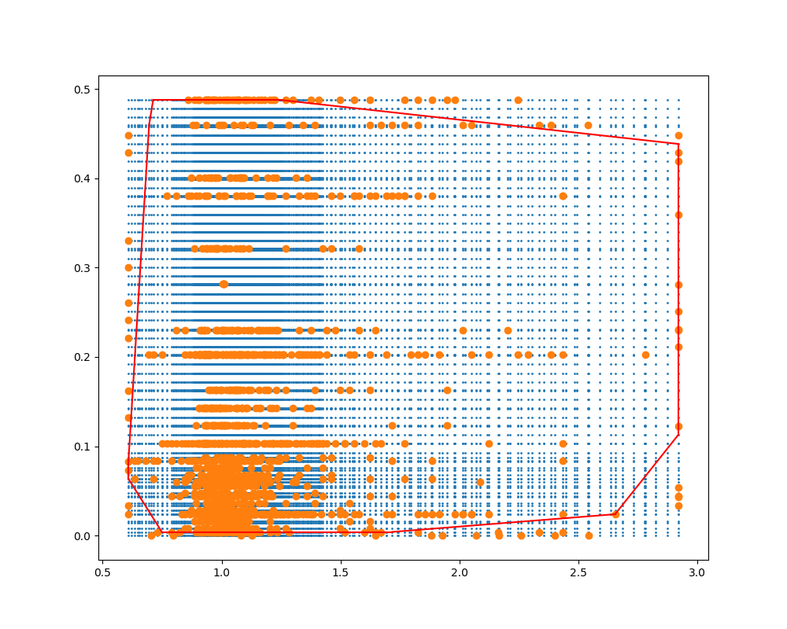

```python
from scipy.spatial import ConvexHull
plt.figure(figsize=(10,8))
plt.scatter(X.flatten(),T.flatten(),s=1)
plt.scatter(test_tot[:,0],test_tot[:,1])
hull = ConvexHull(train_tot[:,0:2])
for simplex in hull.simplices:
     plt.plot(train_tot[simplex, 0], train_tot[simplex, 1], 'r-')
```

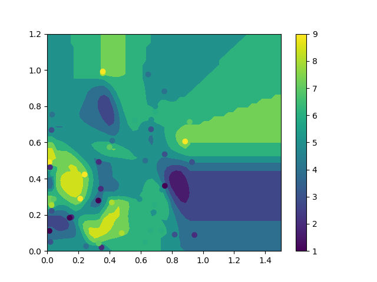

```python
import numpy as np
import scipy
from scipy.interpolate import griddata
import matplotlib.pyplot as plt

def extrapolate_nans(x, y, v):
    '''
    Extrapolate the NaNs or masked values in a grid INPLACE using nearest
    value.

    .. warning:: Replaces the NaN or masked values of the original array!

    Parameters:

    * x, y : 1D arrays
        Arrays with the x and y coordinates of the data points.
    * v : 1D array
        Array with the scalar value assigned to the data points.

    Returns:

    * v : 1D array
        The array with NaNs or masked values extrapolated.
    '''

    if np.ma.is_masked(v):
        nans = v.mask
    else:
        nans = np.isnan(v)
    notnans = np.logical_not(nans)
    v[nans] = scipy.interpolate.griddata((x[notnans], y[notnans]), v[notnans],
        (x[nans], y[nans]), method='nearest').ravel()
    return v


grid_x, grid_y = np.mgrid[0:1.5:50j, 0:1.2:50j]
points = np.random.rand(50, 2)
values = np.random.randint(1,10,50)

x = []
y = []
for i in points:
    x.append(i[0])
    y.append(i[1])
n = plt.Normalize(values.min(), values.max())


grid_z = griddata(points, values, (grid_x, grid_y), method='cubic')
extrapolate_nans(grid_x,grid_y,grid_z)
plt.figure()
plt.contourf(grid_x,grid_y,grid_z)
plt.scatter(x,y,c=values)
plt.colorbar()

plt.show()
```

```python
def find_vol(target_value, call_put, S, K, T, r):
    MAX_ITERATIONS = 100
    PRECISION = 1.0e-5

    sigma = 0.5
    for i in range(0, MAX_ITERATIONS):
        price = bs_price(call_put, S, K, T, r, sigma)
        vega = bs_vega(call_put, S, K, T, r, sigma)

        price = price
        diff = target_value - price  # our root

        print( i, sigma, diff)

        if (abs(diff) < PRECISION):
            return sigma
        sigma = sigma + diff/vega # f(x) / f'(x)

    # value wasn't found, return best guess so far
    return sigma
```

```python
from scipy.stats import norm
import numpy as np
n = norm.pdf
N = norm.cdf

def bs_price(cp_flag,S,K,T,r,v,q=0.0):
    d1 = (np.log(S/K)+(r+v*v/2.)*T)/(v*np.sqrt(T))
    d2 = d1-v*np.sqrt(T)
    if cp_flag == 'c':
        price = S*np.exp(-q*T)*N(d1)-K*np.exp(-r*T)*N(d2)
    else:
        price = K*np.exp(-r*T)*N(-d2)-S*np.exp(-q*T)*N(-d1)
    return price

def bs_vega(cp_flag,S,K,T,r,v,q=0.0):
    d1 = (np.log(S/K)+(r+v*v/2.)*T)/(v*np.sqrt(T))
    return S * np.sqrt(T)*n(d1)
```

```python
V_market = 371.813
K = 2550
T = 0.05555
S = 2919.4
r = 0.0167
cp = 'c' # call option

implied_vol = find_vol(V_market, cp, S, K, T, r)

print( 'Implied vol: %.2f%%' % (implied_vol * 100))

print( 'Market price = %.2f' % V_market)
print( 'Model price = %.2f' % bs_price(cp, S, K, T, r, implied_vol))
```

[output not shown]

[output cut: 88 more lines]

```python
import pickle
import numpy as np

Total_error_u_test_num = 0
Total_error_u_test_den = 0


for j in range(1,5):
    file = open('Real_4_l_30_n_%d_fold_nn_fitsolver_alpha_%d_all_6_months_trimmed_rep','rb')
    data = pickle.load(file)
    file.close()

    u_test_tot = data['u_test_tot']
    u_test_pred = data['u_test_pred']
    K_test_tot = data['K_test_tot']
    alpha_opt = data['alpha']

    error_u_test_num = (np.linalg.norm(u_test_tot*K_test_tot-u_test_pred*K_test_tot))**2
    error_u_test_den = (np.linalg.norm(u_test_tot*K_test_tot))**2
    print('%.4e '%np.sqrt(error_u_test_num/error_u_test_den) + '(\u03B1 = %.2f)'%alpha_opt)
    #print('alpha_opt = %s'%alpha_opt)
    #print('\n')
    Total_error_u_test_num += error_u_test_num
    Total_error_u_test_den += error_u_test_den

print('%.4e'%np.sqrt(Total_error_u_test_num/Total_error_u_test_den))
```

```
7.8022e-03 (α = 0.50)
7.8022e-03 (α = 0.50)
7.8022e-03 (α = 0.50)
7.8022e-03 (α = 0.50)
7.8022e-03
```

```python
0.04*2000**0.2
```

```
0.18292202077093056
```

```python
import pickle
import numpy as np

Total_error_u_test_num = 0
Total_error_u_test_den = 0

for j in range(1,5):
    file = open('Real_4_l_30_n_1_fold_nn_fitsolver_alpha_3_all_6_months_trimmed_rep(with_train)'%(j),'rb')
    data = pickle.load(file)
    file.close()

    u_test_tot = data['u_test_tot']
    u_test_pred = data['u_test_pred']
    K_test_tot = data['K_test_tot']
    alpha_opt = data['alpha']

    error_u_test_num = (np.linalg.norm(u_test_tot*K_test_tot-u_test_pred*K_test_tot))**2
    error_u_test_den = (np.linalg.norm(u_test_tot*K_test_tot))**2
    print('%.4e '%np.sqrt(error_u_test_num/error_u_test_den) + '(\u03B1 = %.2f)'%alpha_opt)
    #print('alpha_opt = %s'%alpha_opt)
    #print('\n')
    Total_error_u_test_num += error_u_test_num
    Total_error_u_test_den += error_u_test_den

print('%.4e'%np.sqrt(Total_error_u_test_num/Total_error_u_test_den))
```

[output not shown]

```python
import pickle
import numpy as np
for i in range(1,5):

    Total_error_u_test_num = 0
    Total_error_u_test_den = 0
    error_bar = '|'
    for j in range(1,6):
        file = open('Real_4_l_30_n_%d_fold_nn_fitsolver_alpha_%d_all_6_months_trimmed_rep'%(i,j),'rb')
        data = pickle.load(file)
        file.close()

        X_u_test_1 = data['X_u_test_1']
        u_test_tot = data['u_test_tot']
        u_test_pred = data['u_test_pred']
        K_test_tot = data['K_test_tot']
        #sigma = data['sigma']

        data = np.concatenate((X_u_test_1,u_test_pred,u_test_tot,K_test_tot))

        error_u_test_num = (np.linalg.norm(u_test_tot*K_test_tot-u_test_pred*K_test_tot))**2
        error_u_test_den = (np.linalg.norm(u_test_tot*K_test_tot))**2
        error = ' %.4e |'%(np.sqrt(error_u_test_num/error_u_test_den))
        #print('%.4e |'%np.sqrt(error_u_test_num/error_u_test_den))

        error_bar = error_bar + error

        #print(error_bar)

        #Total_error_u_test_num += error_u_test_num
        #Total_error_u_test_den += error_u_test_den

    #error_bar = error_bar + ' %.4e |'%np.sqrt(Total_error_u_test_num/Total_error_u_test_den)
    print(error_bar)
    #print('%.4e'%np.sqrt(Total_error_u_test_num/Total_error_u_test_den))
    #print('\n')

import pickle
import numpy as np
error_bar = '|'
for i in range(1,6):

    Total_error_u_test_num = 0
    Total_error_u_test_den = 0

    for j in range(1,5):
        file = open('Real_4_l_30_n_%d_fold_nn_fitsolver_alpha_%d_all_6_months_trimmed_rep'%(j,i),'rb')
        data = pickle.load(file)
        file.close()

        X_u_test_1 = data['X_u_test_1']
        u_test_tot = data['u_test_tot']
        u_test_pred = data['u_test_pred']
        K_test_tot = data['K_test_tot']

        data = np.concatenate((X_u_test_1,u_test_pred,u_test_tot,K_test_tot))

        error_u_test_num = (np.linalg.norm(u_test_tot*K_test_tot-u_test_pred*K_test_tot))**2
        error_u_test_den = (np.linalg.norm(u_test_tot*K_test_tot))**2

        Total_error_u_test_num += error_u_test_num
        Total_error_u_test_den += error_u_test_den
    error = ' %.4e |'%np.sqrt(Total_error_u_test_num/Total_error_u_test_den)
    error_bar = error_bar + error
print(error_bar)
```

```
| 4.6356e-02 | 8.5104e-03 | 7.8024e-03 | 7.8428e-03 | 7.7379e-03 |
| 3.6737e-02 | 7.6613e-03 | 7.4700e-03 | 7.3512e-03 | 7.4254e-03 |
| 4.2218e-02 | 7.6613e-03 | 7.3932e-03 | 7.3019e-03 | 7.3986e-03 |
| 4.4514e-02 | 7.6657e-03 | 7.4374e-03 | 7.3161e-03 | 7.4794e-03 |
| 4.2458e-02 | 7.8716e-03 | 7.5228e-03 | 7.4497e-03 | 7.5068e-03 |
```

```python
import pickle
import numpy as np
for i in range(1,5):

    Total_error_u_test_num = 0
    Total_error_u_test_den = 0
    error_bar = '|'
    for j in range(1,6):
        file = open('Real_4_l_30_n_%d_fold_nn_fitsolver_alpha_%d_all_6_months_trimmed_rep_rev(with_train)'%(i,j),'rb')
        data = pickle.load(file)
        file.close()

        X_u_test_1 = data['X_u_test_1']
        u_test_tot = data['u_test_tot']
        u_test_pred = data['u_test_pred']
        K_test_tot = data['K_test_tot']
        #sigma = data['sigma']

        ###############################get the right X_test_tot instead of X_u_test_1
        #infile = open('Real_data_1_all_6_months_trimmed_4_folds_rev','rb')
        #data = pickle.load(infile)
        #infile.close()
        #
        #Data_test = data['Data_test']
        #Data_train = data['Data_train']
        #bd_train = data['bd_train']
        #bd_test = data['bd_test']
        #ini_train = data['ini_train']
        #ini_test = data['ini_test']
        #
        #data = np.concatenate((Data_test[i-1],bd_test[i-1],ini_test[i-1]))
        #X_test_tot = data[:,0:2]
        #
        ##Remove boundary points
        #data = np.hstack([X_test_tot, u_test_pred, u_test_tot, K_test_tot])
        #data = data[data[:,0] != min(data[:,0])]
        #data = data[data[:,0] != max(data[:,0])]
        #data = data[data[:,1] != min(data[:,1])]
        #
        #u_test_pred = data[:,2]
        #u_test_tot = data[:,3]
        #K_test_tot = data[:,4]
        ################################


        error_u_test_num = (np.linalg.norm(u_test_tot*K_test_tot-u_test_pred*K_test_tot))**2
        error_u_test_den = (np.linalg.norm(u_test_tot*K_test_tot))**2
        error = ' %.4e |'%(np.sqrt(error_u_test_num/error_u_test_den))
        #print('%.4e |'%np.sqrt(error_u_test_num/error_u_test_den))

        error_bar = error_bar + error

        #print(error_bar)

        #Total_error_u_test_num += error_u_test_num
        #Total_error_u_test_den += error_u_test_den

    #error_bar = error_bar + ' %.4e |'%np.sqrt(Total_error_u_test_num/Total_error_u_test_den)
    print(error_bar)
    #print('%.4e'%np.sqrt(Total_error_u_test_num/Total_error_u_test_den))
    #print('\n')

import pickle
import numpy as np
error_bar = '|'
for i in range(1,6):

    Total_error_u_test_num = 0
    Total_error_u_test_den = 0

    for j in range(1,5):
        file = open('Real_4_l_30_n_%d_fold_nn_fitsolver_alpha_%d_all_6_months_trimmed_rep_rev(with_train)'%(j,i),'rb')
        data = pickle.load(file)
        file.close()

        u_test_tot = data['u_test_tot']
        u_test_pred = data['u_test_pred']
        K_test_tot = data['K_test_tot']

        ###################################
        #infile = open('Real_data_1_all_6_months_trimmed_4_folds_rev','rb')
        #data = pickle.load(infile)
        #infile.close()
        #
        #Data_test = data['Data_test']
        #Data_train = data['Data_train']
        #bd_train = data['bd_train']
        #bd_test = data['bd_test']
        #ini_train = data['ini_train']
        #ini_test = data['ini_test']
        #
        #data = np.concatenate((Data_test[j-1],bd_test[j-1],ini_test[j-1]))
        #X_test_tot = data[:,0:2]
        #
        ##Remove boundary points
        #data = np.hstack([X_test_tot, u_test_pred, u_test_tot, K_test_tot])
        #data = data[data[:,0] != min(data[:,0])]
        #data = data[data[:,0] != max(data[:,0])]
        #data = data[data[:,1] != min(data[:,1])]
        #
        #u_test_pred = data[:,2]
        #u_test_tot = data[:,3]
        #K_test_tot = data[:,4]
        ##################################

        error_u_test_num = (np.linalg.norm(u_test_tot*K_test_tot-u_test_pred*K_test_tot))**2
        error_u_test_den = (np.linalg.norm(u_test_tot*K_test_tot))**2

        Total_error_u_test_num += error_u_test_num
        Total_error_u_test_den += error_u_test_den
    error = ' %.4e |'%np.sqrt(Total_error_u_test_num/Total_error_u_test_den)
    error_bar = error_bar + error
print(error_bar)
```

```
| 1.4012e-01 | 1.3840e-02 | 9.1625e-03 | 7.5346e-03 | 3.9252e-03 |
| 1.4377e-01 | 9.2168e-03 | 9.9189e-03 | 8.2736e-03 | 4.0911e-03 |
| 1.4319e-01 | 1.2943e-02 | 8.9039e-03 | 6.5162e-03 | 3.4428e-03 |
| 1.4711e-01 | 1.5004e-02 | 1.1102e-02 | 6.6545e-03 | 4.2366e-03 |
| 1.4363e-01 | 1.2982e-02 | 9.8022e-03 | 7.2358e-03 | 3.9223e-03 |
```

```python
file = open('Real_4_l_30_n_%d_fold_nn_fitsolver_alpha_%d_all_6_months_trimmed_rep'%(j,i),'rb')
data = pickle.load(file)
file.close()

u_test_tot = data['u_test_tot']
u_test_pred = data['u_test_pred']
K_test_tot = data['K_test_tot']

infile = open('Real_data_1_all_6_months_trimmed_4_folds','rb')
data = pickle.load(infile)
infile.close()

Data_test = data['Data_test']
Data_train = data['Data_train']
bd_train = data['bd_train']
bd_test = data['bd_test']
ini_train = data['ini_train']
ini_test = data['ini_test']

data = np.concatenate((Data_test[3],bd_test[3],ini_test[3]))
X_test_tot = data[:,0:2]

#Remove boundary points
data = np.hstack([X_test_tot, u_test_pred, u_test_tot, K_test_tot])
data = data[data[:,0] != min(data[:,0])]
data = data[data[:,0] != max(data[:,0])]
data = data[data[:,1] != min(data[:,1])]
```